# GEOG891_Lab2_Yoo

Kwang il Yoo

9/27/2021

## Load Packages

```r
library(tidyverse)
library(tmap)
library(sf)
```

## Tasks

```r
# load data
counties <- sf::read_sf("../data/CBW/County_Boundaries.shp") %>% sf::st_make_valid()
dams <- sf::read_sf("../data/CBW/Dam_or_Other_Blockage_Removed_2012_2017.shp") %>% sf::st_make_valid()
streams <- sf::read_sf("../data/CBW/Streams_Opened_by_Dam_Removal_2012_2017.shp") %>% sf::st_make_valid()
bmps <- read_csv("../data/CBW/BMPreport2016_landbmps.csv")
```

### Task 1: Aspatial operations

#### 1.1 Calculate summary statistics for the Cost of BMPs for each State (including DC)

```r
totalC <- bmps %>% group_by(StateAbbreviation) %>% summarise(Cost)
by(totalC, totalC$StateAbbreviation, summary)
```

```
## totalC$StateAbbreviation: DC
##  StateAbbreviation       Cost
##  Length:712         Min.   :      0.1
##  Class :character   1st Qu.:     26.7
##  Mode  :character   Median :    628.6
##                     Mean   :  22192.8
##                     3rd Qu.:   5000.7
##                     Max.   :1891063.7
##                     NA's   :8
## ------------------------------------------------------------
## totalC$StateAbbreviation: DE
##  StateAbbreviation       Cost
##  Length:1585        Min.   :      0
##  Class :character   1st Qu.:     16
##  Mode  :character   Median :    906
##                     Mean   :  30682
##                     3rd Qu.:  11574
##                     Max.   :5041838
##                     NA's   :238
## ------------------------------------------------------------
## totalC$StateAbbreviation: MD
##  StateAbbreviation       Cost
##  Length:13958       Min.   :       0
##  Class :character   1st Qu.:       2
##  Mode  :character   Median :     876
##                     Mean   :   53118
##                     3rd Qu.:   10229
##                     Max.   :12086857
##                     NA's   :2151
## ------------------------------------------------------------
## totalC$StateAbbreviation: NY
##  StateAbbreviation       Cost
##  Length:2600        Min.   :     0.0
##  Class :character   1st Qu.:   335.1
##  Mode  :character   Median :  1954.4
##                     Mean   :  8128.7
##                     3rd Qu.:  6978.7
##                     Max.   :622138.0
##                     NA's   :721
## ------------------------------------------------------------
```

[output cut: 14 more lines]

```
##  Mode  :character   Median :      15
##                     Mean   :   25380
##                     3rd Qu.:    1240
##                     Max.   :39731974
##                     NA's   :7002
## ------------------------------------------------------------
## totalC$StateAbbreviation: WV
##  StateAbbreviation       Cost
##  Length:2261        Min.   :       0
##  Class :character   1st Qu.:       0
##  Mode  :character   Median :      97
##                     Mean   :   50014
##                     3rd Qu.:    1176
##                     Max.   :15796521
##                     NA's   :601
```

#### 1.2 Make a scatterplot of Cost vs. TotalAmountCredited, ONLY FOR Units of type “Acres”. You may need to apply a data transformation to one or more axes if the data are heavily skewed.

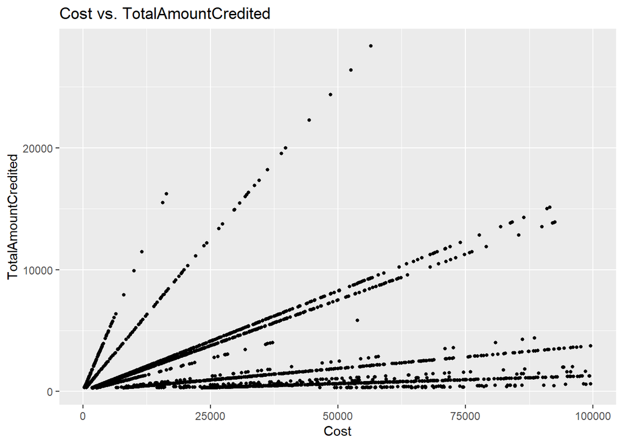

```r
options(scipen = 5)
acres.bmps <- bmps %>% dplyr::filter(Unit == 'Acres', Cost > 0 & Cost < 100000, TotalAmountCredited > 300 & TotalAmountCredited < 30000)
p1 <- ggplot(acres.bmps, aes(x=Cost, y=TotalAmountCredited)) +
    geom_point(size=1) + labs(x= "Cost",
                              y="TotalAmountCredited",
                              title = "Cost vs. TotalAmountCredited")
p1
```

#### 1.3 Make a boxplot with “StateAbbreviation” on the x-axis and “TotalAmountCredited” on the y-axis. HOWEVER, the only data I want plotted are for cover crop BMPs. Note, there are many types of cover crops in this dataset, and I want you to include them ALL. There are handy functions within the stringr package that can help you here.

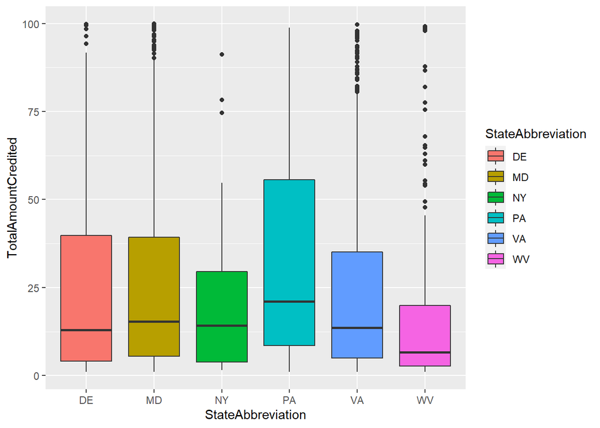

```r
detect.bmps <- bmps %>% mutate(., findCC = stringr::str_detect(BMP, "Cover Crop", negate = F))
filter.bmps <- detect.bmps %>% dplyr::filter(findCC == T, TotalAmountCredited > 1 & TotalAmountCredited < 100)
p2 <- filter.bmps %>% ggplot(., aes(x = StateAbbreviation, y = TotalAmountCredited)) + geom_boxplot(aes(fill = StateAbbreviation))
p2
```

#### 1.4 make a scatterplot of the dam dataset, this time with “YEAR” on the x-axis and “STATE” on y-axis (think of it like a timeline). Assume no dams were built in year 0, so you’ll need to remove those data points.

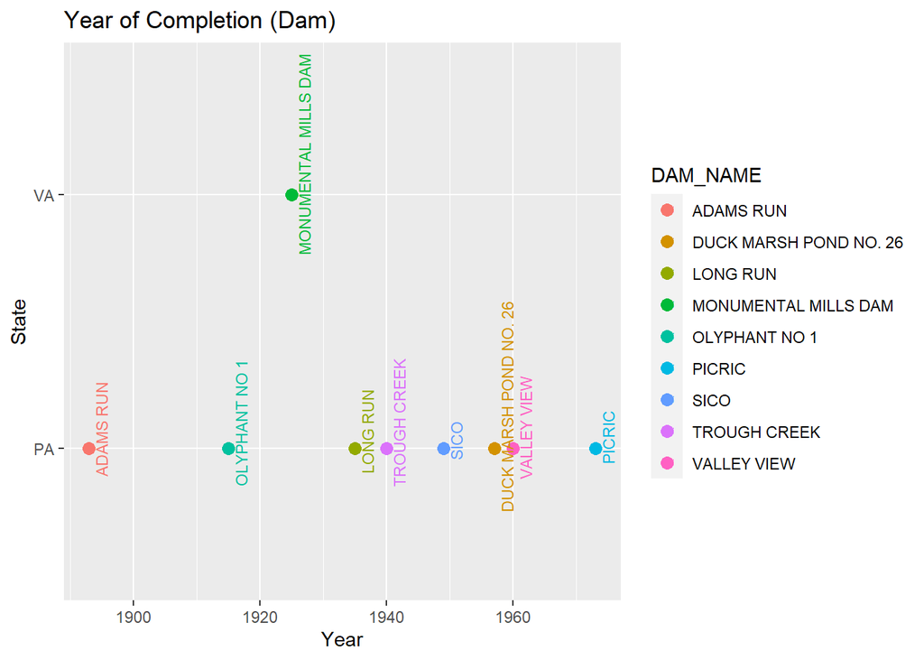

```r
filter.dams <- dams %>% dplyr::filter(YEAR > 1000)
p3 <- ggplot(filter.dams, aes(x=YEAR, y=STATE, label = DAM_NAME, color = DAM_NAME)) +
    geom_point(size=3) + labs(x= "Year",
                              y="State",
                              title = "Year of Completion (Dam)")
p3 + geom_text(hjust = 0.3, vjust = 1.5, nudge_x = 0, angle = 90, size = 3)
```

#### 1.5 make one last (aspatial) visualization. But this time, it’s your choice what data and plots to use. The only requirement is that you link two of the datasets together in some manner. Be creative. Make it look nice (e.g., use proper labels, interesting colors/shading/size).

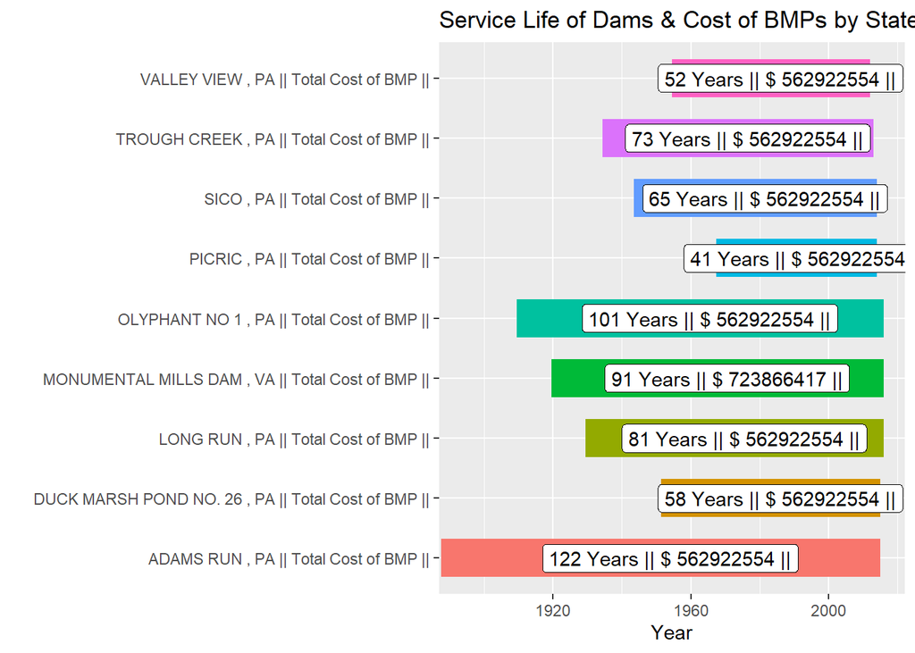

```r
dams1 <- dams %>% as_tibble() %>% dplyr::select(-geometry)
bmps1 <- bmps %>% group_by(StateAbbreviation) %>% summarise(tcost = sum(Cost, na.rm = T))
t.joined3 <- left_join(dams1, bmps1, by = c("STATE" = "StateAbbreviation"))
filter.dams <- t.joined3 %>% dplyr::filter(YEAR > 1000)
filter.dams$tcost <- round(filter.dams$tcost, 0)
filter.dams$DAM_STATE <- paste(DAM_STATE = filter.dams$DAM_NAME,",", filter.dams$STATE, "|| Total Cost of BMP ||")

p4 <- ggplot() + geom_rect(data=filter.dams, aes(xmin=YEAR, xmax=DamRemoval, ymin=DAM_STATE, ymax=DAM_STATE, color=DAM_STATE),size=10) +
  labs(x= "Year", y="", title = "Service Life of Dams & Cost of BMPs by State")

p4 + geom_label(data = filter.dams, aes(x = YEAR + (DamRemoval-YEAR)/2, y = DAM_STATE, label = paste(DamRemoval-YEAR, "Years", "|| $", filter.dams$tcost, "||"))) + theme(legend.position="none")
```

### Task 2: Spatial operations

#### 2.1 Find the 5 longest streams in the ‘streams opened by dam removal’ dataset

```r
long.streams <- streams %>% as_tibble() %>% dplyr::select(-geometry) %>% group_by(GNIS_Name) %>% summarise(totalLength = sum(LengthKM))
na.long.streams <- na.omit(long.streams)
s.long.streams <- arrange(na.long.streams, desc(totalLength))
head(s.long.streams, 5)
```

```
## # A tibble: 5 x 2
##   GNIS_Name           totalLength
##   <chr>                     <dbl>
## 1 Hazel River                45.4
## 2 South River                44.7
## 3 Great Trough Creek         43.5
## 4 Hughes River               22.5
## 5 Little Trough Creek        22.2
```

```r
streams <- streams %>% mutate(totalLength = st_length(streams))
long.streams <- streams %>% as_tibble() %>% group_by(GNIS_Name) %>% summarise(totalLength = sum(totalLength))
na.long.streams <- na.omit(long.streams)
s.long.streams <- arrange(na.long.streams, desc(totalLength))
head(s.long.streams, 5)
```

```
## # A tibble: 5 x 2
##   GNIS_Name           totalLength
##   <chr>                       [m]
## 1 Hazel River              45412.
## 2 South River              44791.
## 3 Great Trough Creek       43501.
## 4 Hughes River             22472.
## 5 Little Trough Creek      22125.
```

#### 2.2 Find the three counties with the greatest TOTAL length of streams (opened by dam removal) in them

```r
joined <- st_join(streams, counties, join = st_intersects)
long.joined <- joined %>% as_tibble() %>% dplyr::select(-geometry) %>% group_by(NAME10) %>% summarise(totalLength = sum(LengthKM))
s.long.streams <- arrange(long.joined, desc(totalLength))
head(s.long.streams, 3)
```

```
## # A tibble: 3 x 2
##   NAME10     totalLength
##   <chr>            <dbl>
## 1 Augusta           425.
## 2 Huntingdon        309.
## 3 Cameron           242.
```

```r
streams <- streams %>% mutate(totalLength = st_length(streams))
joined <- st_join(streams, counties, join = st_intersects)
long.joined <- joined %>% as_tibble() %>% group_by(NAME10) %>% summarise(totalLength = sum(totalLength))
s.long.streams <- arrange(long.joined, desc(totalLength))
head(s.long.streams, 3)
```

```
## # A tibble: 3 x 2
##   NAME10     totalLength
##   <chr>              [m]
## 1 Augusta        424897.
## 2 Huntingdon     308558.
## 3 Cameron        241557.
```

#### 2.3 Make a map of the counties, shading each county by the total cost of BMPs funded/implemented in that county. This will required you to join multiple datasets together

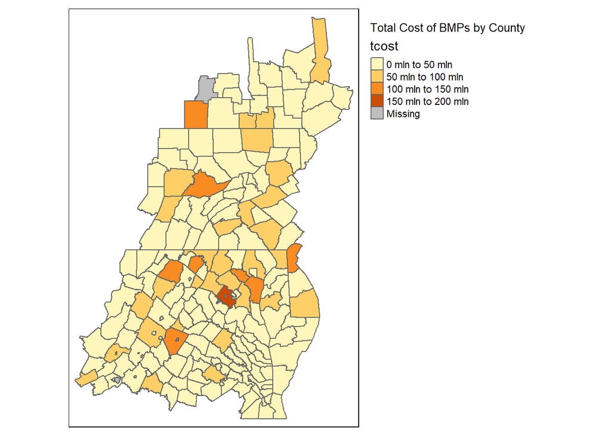

```r
bmps_trim <- bmps %>% mutate(., FIPS.trimmed = stringr::str_sub(GeographyName, 3, 5)) %>% group_by(FIPS.trimmed) %>% summarise(tcost = sum(Cost, na.rm = T))
counties_bmps <- left_join(counties, bmps_trim, by = c("COUNTYFP10" = "FIPS.trimmed"))
counties_bmps$tcost <- as.integer(counties_bmps$tcost)
tm_shape(counties_bmps) + tm_polygons(col = "tcost") + tm_layout(title = "Total Cost of BMPs by County",legend.outside = TRUE)
```

#### 2.4 For each removed dam, find the closest stream segment

```r
nearest <- st_nearest_feature(dams, streams)
dsjoin <- cbind(dams, st_drop_geometry(streams)[nearest,])
nearpts <- dsjoin %>% mutate(ClosestStreamID = OBJECTID_1.1) %>% summarise(DAM_NAME, ClosestStreamID, geometry, GNIS_Name)
print(nearpts, n=40)
```

```
## Simple feature collection with 34 features and 3 fields
## Geometry type: POINT
## Dimension:     XY
## Bounding box:  xmin: -79.03091 ymin: 37.23352 xmax: -75.53803 ymax: 41.71974
## Geodetic CRS:  WGS 84
##                         DAM_NAME ClosestStreamID
## 1               BARREN CREEK DAM            5896
## 2              KLADDER RESERVOIR            8326
## 3                Lake Lehman Dam            7554
## 4                         PICRIC            8125
## 5         DUCK MARSH POND NO. 26            7601
## 6                       LONG RUN            8510
## 7                   TROUGH CREEK            8532
## 8                  OLYPHANT NO 1            8517
## 9               HEISTAND SAWMILL            7543
```

[output cut: 60 more lines]

#### 2.5 Calculate how many removed dams are (or were) in each state

```r
dams %>% group_by(STATE) %>% summarise(count = n()) %>% arrange(desc(count))
```

```
## Simple feature collection with 3 features and 2 fields
## Geometry type: MULTIPOINT
## Dimension:     XY
## Bounding box:  xmin: -79.03091 ymin: 37.23352 xmax: -75.53803 ymax: 41.71974
## Geodetic CRS:  WGS 84
## # A tibble: 3 x 3
##   STATE count                                                           geometry
##   <chr> <int>                                                   <MULTIPOINT [°]>
## 1 PA       27 ((-75.53803 41.46384), (-75.90023 41.20816), (-76.05354 41.6335),~
## 2 VA        5 ((-77.41335 37.23352), (-78.89962 38.05994), (-78.89175 38.05944)~
## 3 MD        2                          ((-75.73443 38.4618), (-76.06189 39.048))
```